# Report: act_report

### Analyzing & visualizing WeRateDogs twitter archive data

This report will infer from the insights and displayed visualizations produced from WeRateDogs twitter archive data Wrangling and Analyzing project.

**Dog_stages by count**

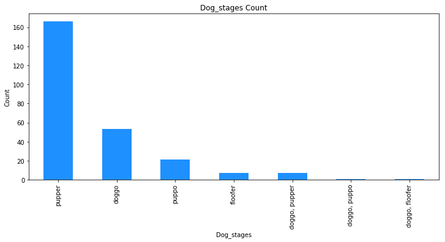

From the table above, it is evident that majority of the WeRateDogs dogs are in pupper stage by 65%, followed by doggo stage and least popular dog stage doggo-floofer.

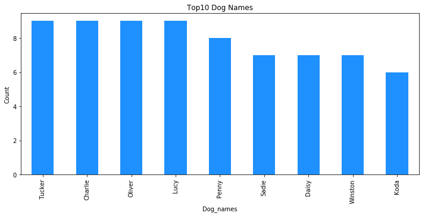

**Relationship between Favorite and Retweet**

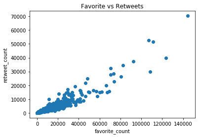

The above plot shows a positive correlation between favorite(likes) count and retweet count posted by WeRateDogs. As the favorite count tends to increase the retweet count increases. Having see that a heatmap is plotted below to examine how strong the positive correlation between favorite count and retweet count is.

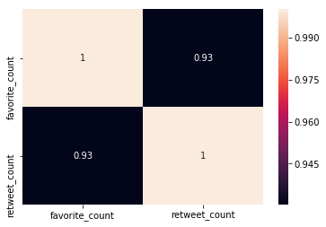

From the heatmap plot above, shows a very strong positive correlation between favorite count and retweet count by 93% or vice versa.

**Twitter Source**

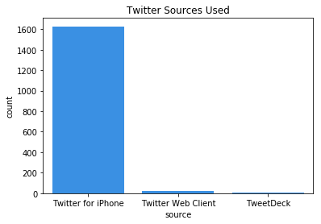

The plot above shows that most of WeRateDogs tweets were posted using an iPhone majority of time by 98%.